# Lab 8 r code

2022-03-17

```r
# install.packages('tidygraph')
# install.packages('ggraph')
# install.packages('igraph')
library(tidygraph)
library(ggraph)
library(igraph)
# Load surveillance network data

nodes = read.csv('./swedish gang networks/SURnodes.csv')
edges = read.csv('./swedish gang networks/SURedges.csv')

graph = tbl_graph(nodes = nodes, edges = edges, node_key = 'id')
```

Plot the adjacency matrix

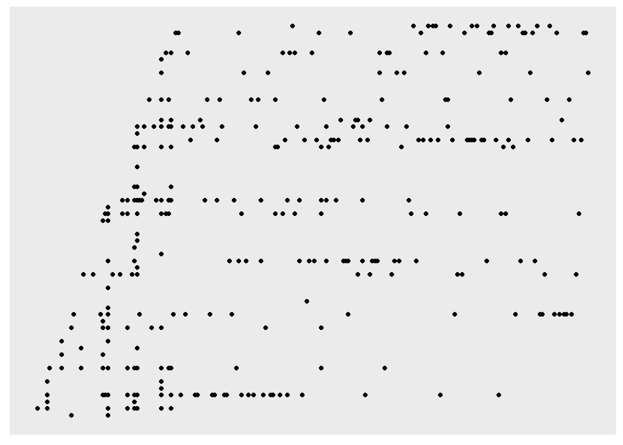

```r
ggraph(graph, layout = 'matrix') +
  geom_edge_point()
```

Visualize network using `ggraph`. There are many choices of “layouts”, or, ways to organize the position of nodes and edges. Choice of layout will depend on structure of the network. Play with some options to see what works.

```
## Using "sugiyama" as default layout
```

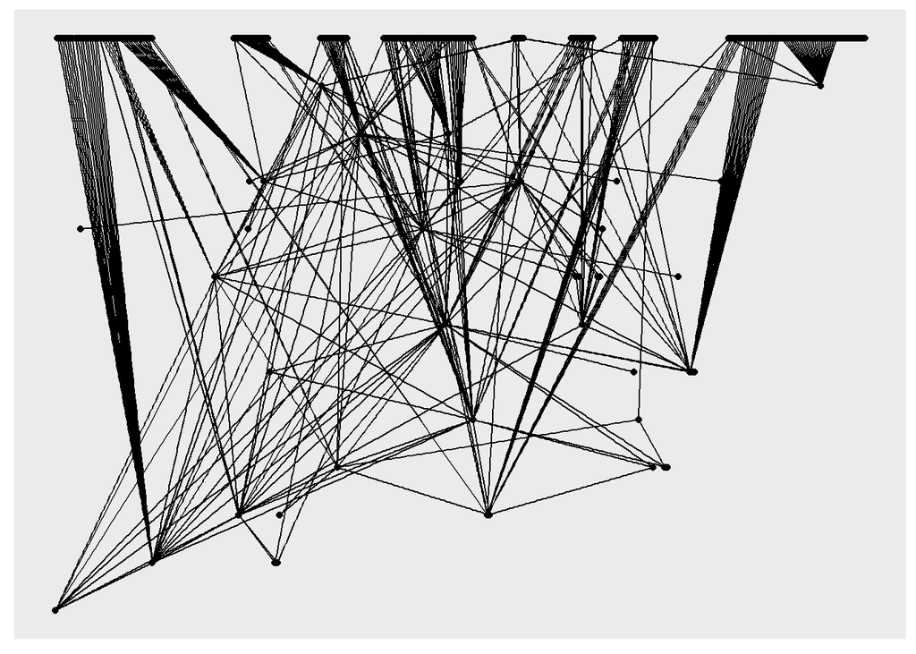

```r
# Three key components to ggraph - nodes, edges, and layout
ggraph(graph) +
  geom_node_point() +
  geom_edge_link()
```

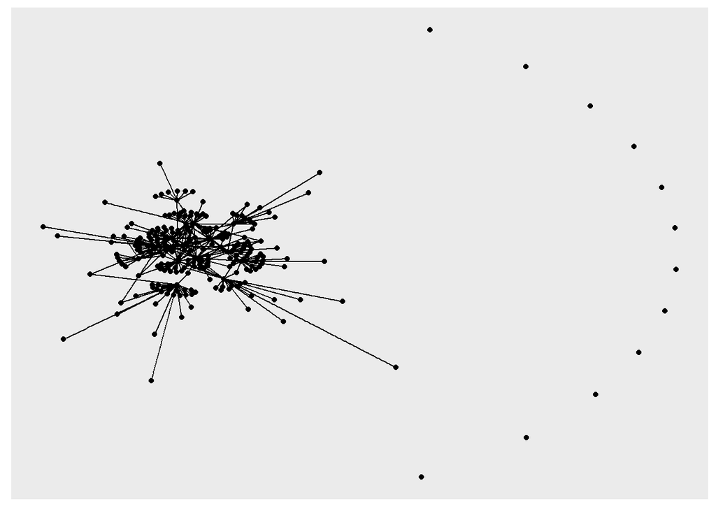

```r
# Try different layout algorithms
ggraph(graph, layout = 'kk') + # spring-based (Kamada & Kawai)
  geom_node_point() +
  geom_edge_link()
```

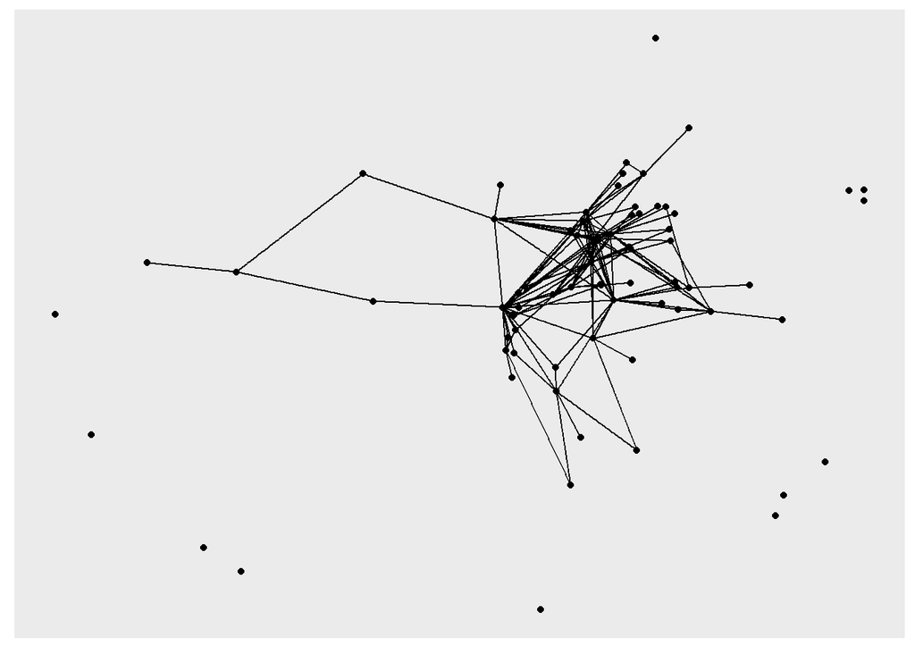

```r
ggraph(graph, layout = 'mds') + # multi-dimensional scaling
  geom_node_point() +
  geom_edge_link()
```

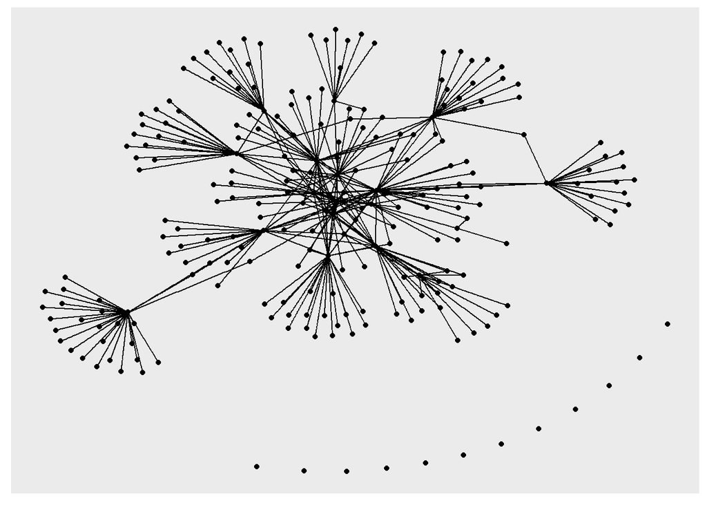

```r
ggraph(graph, layout = 'fr') + # force-directed (Fruchterman & Reingold)
  geom_node_point() +
  geom_edge_link()
```

[Many interesting ways to lay out networks](https://cran.r-project.org/web/packages/ggraph/vignettes/Layouts.html)

Network data are contained in `igraph` objects, which contain data/attributes for each node/vertex and each edge.

```r
class(graph)
```

```
## [1] "tbl_graph" "igraph"
```

```r
# Count number of nodes and edges
vcount(graph)
```

```
## [1] 234
```

```r
ecount(graph)
```

```
## [1] 315
```

```r
# Examine node/vertex and edge attributes
vertex_attr_names(graph)
```

```
## [1] "id"        "n1"        "n2"        "gang"      "hierarchy"
```

```r
edge_attr_names(graph)
```

```
## [1] "weight"
```

“Centrality” measures are one of the first steps in network analysis. They are descriptive statistics. Degree centrality counts number of edges going into or out of each node. Closeness centrality measures the average shortest path from one node to each other node. Betweenness centrality measures the number of times a node acts as a bridge between two other nodes (along the shortest path).

Because centrality describes the nodes, access them using the function `V()` on the graph/network object.

```r
# Compute measures of centrality
# Degree centrality
V(graph)$indegree = degree(graph, mode = 'in')
V(graph)$outdegree = degree(graph, mode = 'out')

# Closeness centrality
V(graph)$closeness = closeness(graph)

# Betweenness centrality
V(graph)$betweenness = betweenness(graph)
```

Centrality measures are now stored as a new attribute in the vertex (node) list.

```r
# Examine node/vertex and edge attributes
vertex_attr_names(graph)
```

```
## [1] "id"          "n1"          "n2"          "gang"        "hierarchy"
## [6] "indegree"    "outdegree"   "closeness"   "betweenness"
```

```r
edge_attr_names(graph)
```

```
## [1] "weight"
```

We can visualize and do statistics on centrality measures like any other type of data. Note that in this particular network, most nodes are only connected to a single other node (many nodes on the “outskirts”)

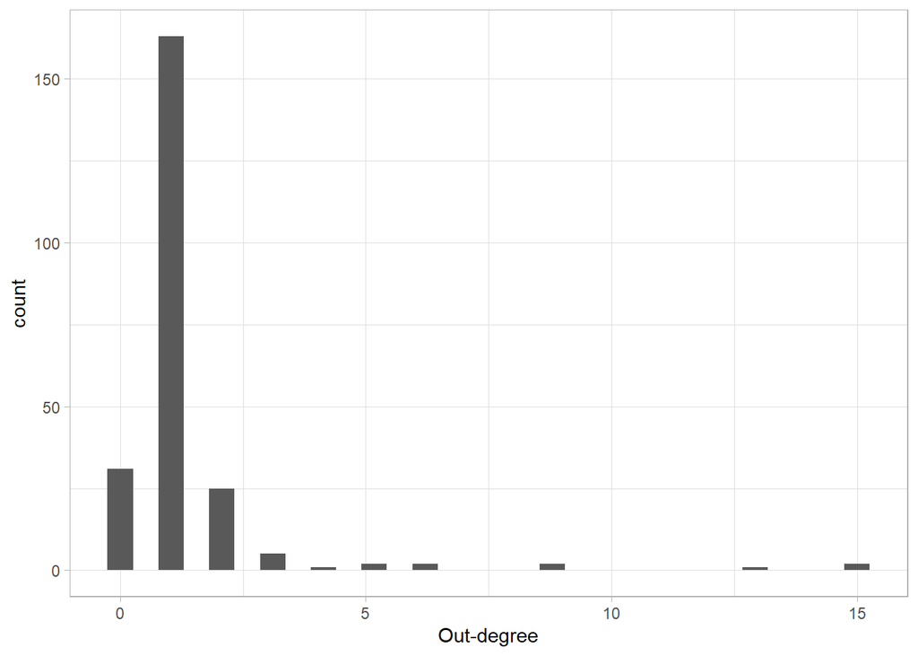

```r
data = as.data.frame((V(graph)$outdegree))
colnames(data) = 'variable'

ggplot(data) +
  aes(x = variable) +
  geom_histogram() +
  theme_light() +
  xlab('Out-degree')
```

Is this distribution surprising given the number of nodes and edges in this network? Does it deviate from a random assignment of connections?

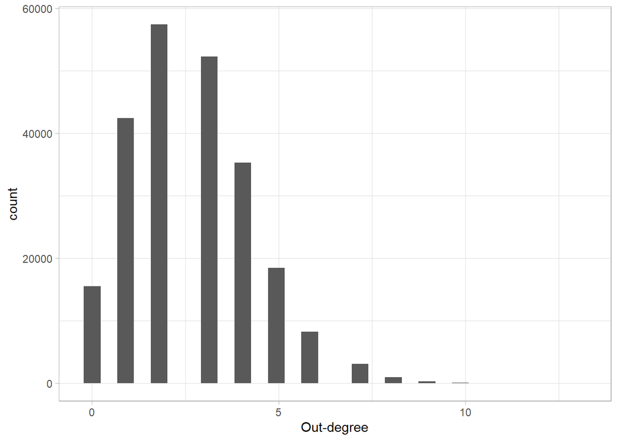

```r
# Get original
nv = vcount(graph)
ne = ecount(graph)
degs = degree(graph, mode = 'out')

ntrials = 1000

result_list = vector(mode = 'list', length = ntrials)
for (i in (1:ntrials))
{
  rand_graph = sample_gnm(nv, ne) # Create random network
  result_list[[i]] = degree(rand_graph, mode = 'out')
}
result_list = unlist(result_list)

ggplot() +
  aes(x = result_list) +
  geom_histogram() +
  theme_light() +
  xlab('Out-degree')
```

We can visualize information about the network by plotting values on the nodes and edges.

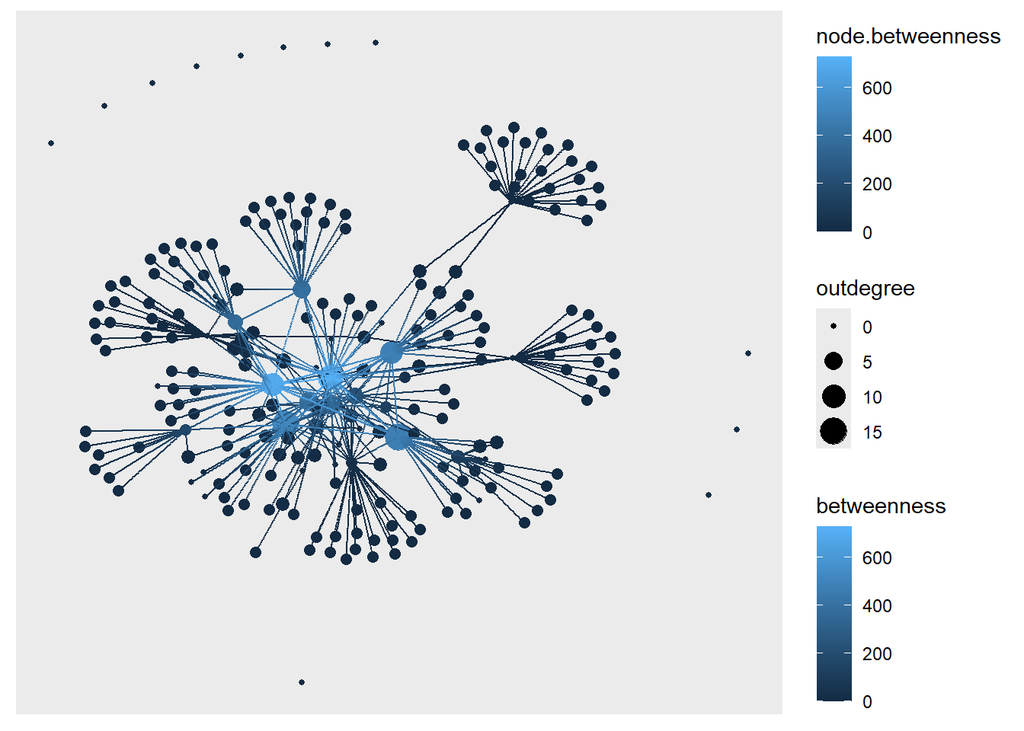

```r
ggraph(graph, layout = 'fr') +
  geom_node_point(aes(size = outdegree, color = betweenness)) +
  geom_edge_fan2(aes(color = node.betweenness))
```

We can visualize other variables about individuals if we have them. Below, the `hierarchy` variable describes position in a gang. If the value is >0, the person is a gang member.

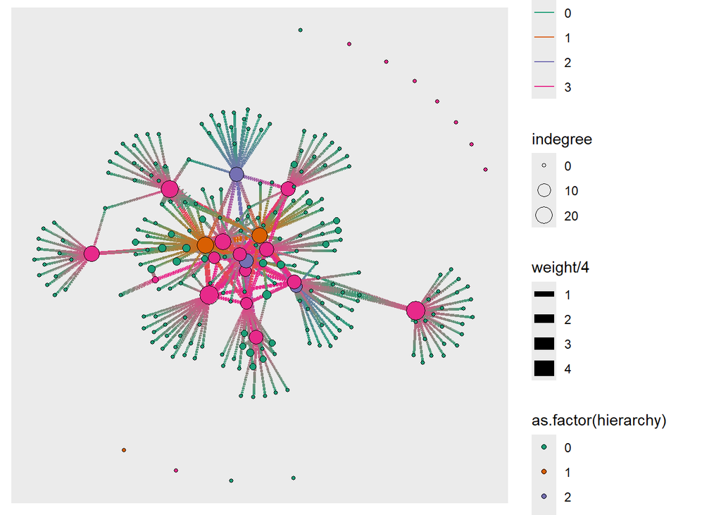

```r
ggraph(graph, layout = 'fr') +
  geom_edge_fan2(aes(color = as.factor(node.hierarchy), edge_width = weight/4)) +
  scale_edge_color_brewer(palette = 'Dark2') +
  geom_node_point(aes(size = indegree, fill = as.factor(hierarchy)), shape = 21, color = 'black') +
  scale_fill_brewer(palette = 'Dark2')
```

Color individuals by their membership in a connected component.

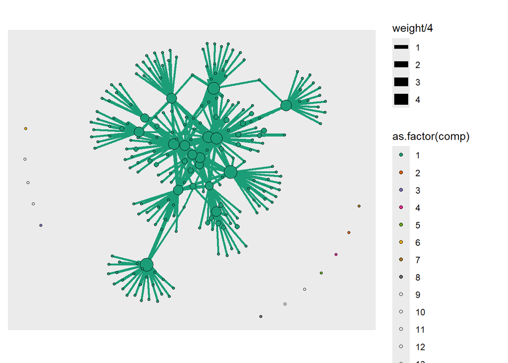

```r
V(graph)$comp = components(graph)$membership

ggraph(graph, layout = 'fr') +
  geom_edge_fan2(aes(color = as.factor(node.comp), edge_width = weight/4)) +
  scale_edge_color_brewer(palette = 'Dark2') +
  geom_node_point(aes(size = indegree, fill = as.factor(comp)), shape = 21, color = 'black') +
  scale_fill_brewer(palette = 'Dark2') +
  coord_fixed()
```

There’s one “giant connected component”, so everyone in the main network is the same color.

Remove nodes with high betweenness to break apart the network. (These might be individuals we’d target in an intervention)

```r
vcount(graph)
```

```
## [1] 234
```

```r
ecount(graph)
```

```
## [1] 315
```

```r
idx = which(V(graph)$betweenness > 100)

graph2 = delete_vertices(graph, idx)

vcount(graph2)
```

```
## [1] 221
```

```r
ecount(graph2)
```

```
## [1] 94
```

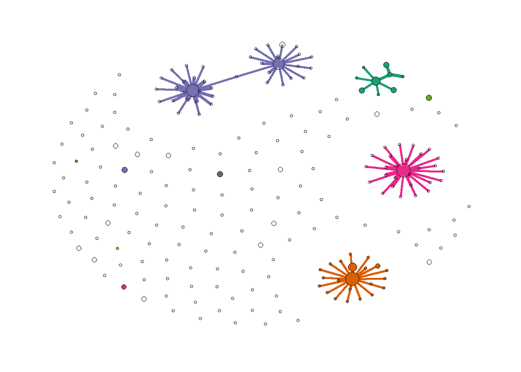

```r
V(graph2)$comp = components(graph2)$membership

ggraph(graph2, layout = 'fr') +
  geom_edge_fan2(aes(color = as.factor(node.comp), edge_width = weight/4), show.legend = FALSE) +
  scale_edge_color_brewer(palette = 'Dark2') +
  geom_node_point(aes(size = indegree, fill = as.factor(comp)), shape = 21, color = 'black', show.legend = FALSE) +
  scale_fill_brewer(palette = 'Dark2') +
  theme_graph()
```

Below, a function to iteratively remove nodes based on centrality measures. We’re going to test the “resilience” of the network

```r
# TAKEN FROM:
#     https://users.dimi.uniud.it/~massimo.franceschet/R/resilience.html
#
percolate = function(g, size, d) {

  giant = vector()

  # initial size of giant component
  c = components(g)
  giant[1] = max(c$csize)

  names(d) = 1:length(d)
  d = sort(d, decreasing=TRUE)
  vital = as.integer(names(d[1:size]))

  for (i in 1:size) {
    c = components(delete_vertices(g, vital[1:i]))
    giant[i+1] = max(c$csize)
  }

  return(giant)

}
```

How sensitive is the network structure to a few key individuals? Assess network cohesion

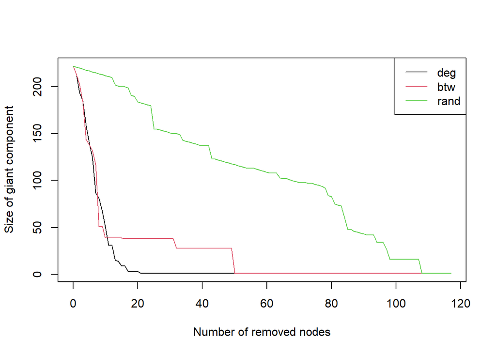

```r
# Resilience/cohesion
size = vcount(graph)/2
# random
rand = percolate(graph, size, d = sample(V(graph), size))
# degree
deg = percolate(graph, size, d = degree(graph))
# betweenness
bet = percolate(graph, size, d = betweenness(graph))

plot(0:size, deg, type = "l", col=1, xlab="Number of removed nodes", ylab="Size of giant component")
lines(0:size, bet, col=2)
lines(0:size, rand, col=3)
legend(x = "topright", legend = c("deg", "btw", "rand"), lty = 1, col = 1:3)
```